# TransHDM: High-Dimensional Mediation Analysis via Transfer Learning

Huer Gao

2026-11-24

## Introduction

`TransHDM` provides a framework for high-dimensional mediation analysis using transfer learning. It integrates external source datasets to improve the detection power of potential mediators in small-sample target studies, addressing data heterogeneity via transfer regularization and debiased estimation.

## Built-in Data

The package includes the simulated inflammatory mediation benchmark dataset with one target cohort and two external cohorts:

- `inflam_target` — target cohort (*n* = 50)
- `inflam_external1` — transferable external cohort (*n* = 200)
- `inflam_external2` — non-transferable external cohort (*n* = 100)
- `inflam_effect` — ground-truth mediation effects

The exposure is an inflammatory biomarker (`IB`) and the outcome is a disease severity index (`DSI`); the 20 candidate mediators are molecular markers across five functional groups. The mediator columns were randomly permuted during generation, so the identity of the truly active mediators is hidden.

```r
library(TransHDM)

data(inflam_target)
data(inflam_external1)
data(inflam_external2)
data(inflam_effect)

target    <- inflam_target
source    <- inflam_external1
source_nt <- inflam_external2

outcome_var  <- "DSI"    # disease severity index (outcome)
exposure_var <- "IB"     # inflammatory biomarker (exposure)
X_vars       <- c("BIS", "PRS", "BRS")
M_vars       <- setdiff(colnames(target),
                        c(outcome_var, exposure_var, X_vars))

## ground truth effect (target cohort)
inflam_effect
```

```
#>    mediator alpha beta alpha_beta
#> 1    CYT_01  0.00 0.00     0.0000
#> 2    CYT_02  0.00 0.00     0.0000
#> 3    CYT_03  0.00 0.00     0.0000
#> 4    CYT_04  0.00 0.00     0.0000
#> 5    IMM_01  0.50 0.50     0.2500
#> 6    IMM_02  0.00 0.00     0.0000
#> 7    IMM_03  0.65 0.45     0.2925
#> 8    IMM_04  0.00 0.00     0.0000
#> 9    OXI_01  0.55 0.45     0.2475
#> 10   OXI_02  0.00 0.35     0.0000
#> 11   OXI_03  0.00 0.00     0.0000
#> 12   OXI_04  0.60 0.40     0.2400
#> 13   MET_01  0.35 0.00     0.0000
#> 14   MET_02  0.00 0.00     0.0000
#> 15   MET_03  0.00 0.00     0.0000
#> 16   MET_04  0.00 0.00     0.0000
#> 17   SIG_01  0.00 0.00     0.0000
#> 18   SIG_02  0.30 0.00     0.0000
#> 19   SIG_03  0.00 0.25     0.0000
#> 20   SIG_04  0.00 0.00     0.0000
```

## Source Detection

Identify which source datasets are transferable to the target population. `print()` gives a concise one-line summary, while `summary()` provides the detailed decision table:

```r
set.seed(123)
detect <- source_detection(target_data = target,
                           source_data = list(source, source_nt),
                           Y = outcome_var, D = exposure_var, M = M_vars, X = X_vars)
```

```
#> Transfer candidate sources: 1
```

```r
print(detect)
```

```
#> Source detection: 1/2 sources transferable
```

```r
summary(detect)
```

```
#> Source detection summary
#> ------------------------
#> Number of sources: 2
#> Number of transferable sources: 1
#>
#> Target validation loss:
#>   mean = 17.3819
#>
#> Threshold:
#>   0.099
#>
#> Source-wise comparison:
#>  Source SourceLoss T_index Transferable
#>       1    15.1041 -2.2779          YES
#>       2    18.7355  1.3536           NO
```

Visualization of the source detection results can be done using the `plot()` function:

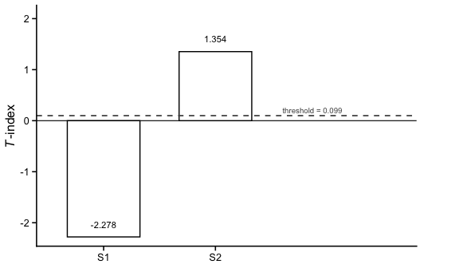

```r
plot(detect)
```

## Integrated Workflow: `TransHDM()`

The `TransHDM()` function provides an end-to-end analysis in one call:

```r
# With transfer learning
set.seed(123)
result_tl <- TransHDM(
  target_data = target,
  source_data = source,
  Y = outcome_var, D = exposure_var,
  M = M_vars, X = X_vars,
  transfer = TRUE,
  topN = 10, p_cutoff = 0.01
)
```

```
#> Step 1: Sure Independence Screening ...  (11:11:26)
#> Top 10 mediators selected: IMM_03, OXI_04, IMM_01, OXI_01, MET_01, SIG_02, CYT_01, CYT_02, CYT_03, CYT_04  (11:11:27)
#> After screening, 10 / 20 mediators are retained.
#> Step 2: De-biased Lasso Estimates ... (11:11:27)
#> Estimation of mediator-outcome effects in the outcome model completed.
#> Estimation of exposure-mediator effects in the mediator model completed.
#> Step 3: Multiple-testing procedure ... (11:11:29)
#> Identified mediator(s): IMM_01, IMM_03, OXI_01, OXI_04
```

```r
print(result_tl)
```

```
#> TransHDM: 4 mediator(s) | TE=2.0067 | IDE=1.0558 | DE=0.9509 | PE=52.61%
```

```r
# summary(result_tl)
```

```r
# Without transfer learning (target only)
set.seed(123)
result_nt <- TransHDM(
  target_data = target,
  Y = outcome_var, D = exposure_var,
  M = M_vars, X = X_vars,
  transfer = FALSE,
  topN = 10, p_cutoff = 0.01
)
```

```
#> Step 1: Sure Independence Screening ...  (11:11:29)
#> Top 10 mediators selected: OXI_01, IMM_01, OXI_04, IMM_03, MET_01, CYT_01, CYT_02, CYT_03, CYT_04, IMM_02  (11:11:29)
#> After screening, 10 / 20 mediators are retained.
#> Step 2: De-biased Lasso Estimates ... (11:11:29)
#> Estimation of mediator-outcome effects in the outcome model completed.
#> Estimation of exposure-mediator effects in the mediator model completed.
#> Step 3: Multiple-testing procedure ... (11:11:30)
#> Identified mediator(s): IMM_01, IMM_03, OXI_01, OXI_04, MET_01
```

```r
print(result_nt)
```

```
#> TransHDM: 5 mediator(s) | TE=2.9371 | IDE=1.7442 | DE=1.1929 | PE=59.39%
```

```r
summary(result_nt)
```

```
#> ====================================================
#>         Summary of TransHDM Mediation Analysis
#> ====================================================
#>
#> Overall Effects:
#>    effect estimate
#>  indirect   1.7442
#>    direct   1.1929
#>     total   2.9371
#>        pe   0.5939
#>
#> Identified Mediators:
#>   Number of selected mediators: 5
#>
#> Top 5 mediators by |alpha * beta|:
#>
#>  mediator  alpha   alpha_pv   beta    beta_pv alpha_beta      ab_pv    fdr_est
#>    IMM_01 0.6709 2.8265e-08 0.6836 4.3975e-12     0.4586 2.8265e-08 2.8289e-08
#>    OXI_04 0.6473 1.0569e-07 0.6086 1.1208e-07     0.3939 1.1208e-07 5.6085e-08
#>    IMM_03 0.7014 1.5277e-08 0.5468 8.5240e-10     0.3835 1.5277e-08 2.8289e-08
#>    OXI_01 0.6797 1.8581e-08 0.5511 5.6821e-08     0.3746 5.6821e-08 3.7938e-08
#>    MET_01 0.5199 2.2920e-05 0.2570 1.1885e-02     0.1336 1.1885e-02 4.7539e-03
#>      pa
#>  0.1562
#>  0.1341
#>  0.1306
#>  0.1275
#>  0.0455
#>
#> Note:
#>   alpha  : exposure-mediator effect
#>   beta   : mediator-outcome effect
#>   ab_pv  : joint p-value, max(alpha_pv, beta_pv)
#>   fdr_est: pointwise FDR from HDMT::fdr_est
#>   pa     : proportion of total effect explained
#>   P-values and fdr_est are shown in scientific notation
#>
#> ====================================================
```

## Visualization

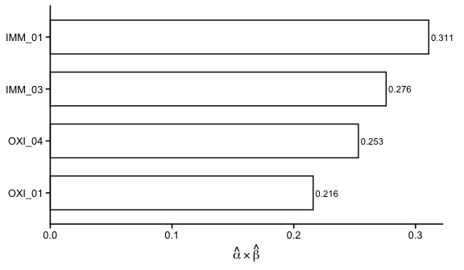

```r
# Mediator-wise effect plot
plot(result_tl, type = "mediator")
```

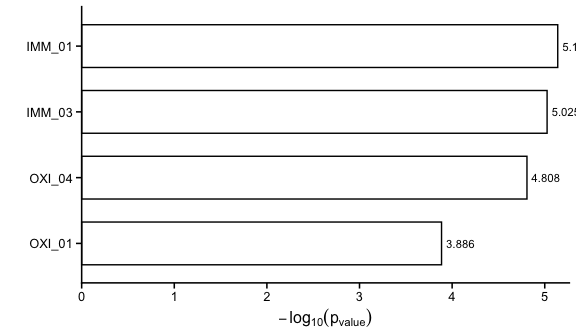

```r
# P-value visualization
plot(result_tl, type = "pvalue")
```

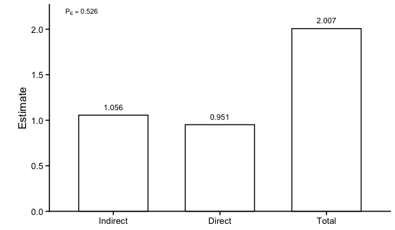

```r
# Overall effect decomposition
plot(result_tl, type = "overall")
```

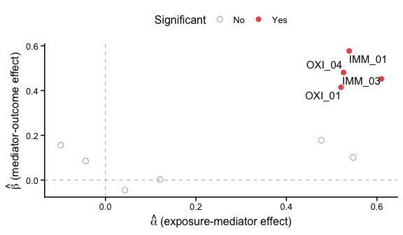

```r
# Alpha-beta effect plot
plot(result_tl, type = "alpha_beta")
```

## Modular Workflow

### Sure Independence Screening (SIS)

Reduce dimensionality by filtering candidate mediators:

```r
set.seed(123)
sis <- SIS(
  target_data = target, source_data = source,
  Y = outcome_var, D = exposure_var, M = M_vars, X = X_vars,
  transfer = TRUE, topN = 10, ncore = 1
)
```

```
#> Step 1: Sure Independence Screening ...  (11:11:31)
#> Top 10 mediators selected: IMM_03, OXI_04, IMM_01, OXI_01, MET_01, SIG_02, CYT_01, CYT_02, CYT_03, CYT_04  (11:11:31)
```

```r
print(sis)
```

```
#> SIS: 10/20 mediators retained (transfer)
```

```r
summary(sis)
```

```
#>
#> Sure Independence Screening (SIS) summary
#> ----------------------------------------
#> Selected mediators:
#>   Number selected: 10
#> Names: IMM_03, OXI_04, IMM_01, OXI_01, MET_01, SIG_02, CYT_01, CYT_02, CYT_03,
#> CYT_04
#>
#> Target data after SIS:
#>   Sample size (n): 50
#>
#> Source data after SIS:
#>   Sample size (n): 200
#>
#> Transfer learning: YES
#> ----------------------------------------
```

### Mediation Effect Inference

Estimate exposure-mediator and mediator-outcome effects:

```r
med_effect <- mediation_inference(
  screen_result = sis,
  transfer = TRUE
)
```

```
#> After screening, 10 / 20 mediators are retained.
#> Step 2: De-biased Lasso Estimates ... (11:11:31)
#> Estimation of mediator-outcome effects in the outcome model completed.
#> Estimation of exposure-mediator effects in the mediator model completed.
```

```r
print(med_effect)
```

```
#> Mediation inference: 10 mediators tested | DE = 0.9509
```

```r
summary(med_effect, top = 10)
```

```
#> ====================================================
#>     Summary of Mediation Estimation and Testing
#> ====================================================
#>
#> Mediators:
#>   Total specified:  20
#>   Retained after screening:  10
#>
#> Direct Effect (DE):
#>   DE_est = 0.9509
#>
#> Top 10 mediators by |alpha * beta|:
#>
#>  mediator   alpha   alpha_pv    beta    beta_pv alpha_beta
#>    IMM_01  0.5387 7.2396e-06  0.5770 6.3782e-07     0.3109
#>    IMM_03  0.6099 6.0300e-07  0.4523 9.4337e-06     0.2759
#>    OXI_04  0.5264 1.1674e-05  0.4808 1.5559e-05     0.2531
#>    OXI_01  0.5207 2.4115e-05  0.4147 1.3012e-04     0.2159
#>    MET_01  0.4773 7.0472e-05  0.1779 1.2422e-01     0.0849
#>    SIG_02  0.5475 6.1962e-06  0.1010 3.6243e-01     0.0553
#>    CYT_01 -0.0990 4.1380e-01  0.1563 1.9403e-01    -0.0155
#>    CYT_03 -0.0440 7.1891e-01  0.0855 4.9918e-01    -0.0038
#>    CYT_04  0.0429 7.2547e-01 -0.0447 7.0832e-01    -0.0019
#>    CYT_02  0.1208 3.2723e-01  0.0027 9.8387e-01     0.0003
#>
#> Note:
#>   alpha   : exposure-mediator effect
#>   beta    : mediator-outcome effect
#>   P-values are shown in scientific notation
#>
#> ====================================================
```

Do effect estimation and inference directly from the source and target data without SIS:

```r
mediation_inference(
  source_data = source, target_data = target,
  Y = outcome_var, D = exposure_var, M = M_vars, X = X_vars,
  transfer = TRUE, ncore = 1
)
```

### Joint Significance Testing

Identify significant mediators through joint multiple testing:

```r
jt <- joint_test(
  inference_result = med_effect,
  p_cutoff = 0.05
)
```

```
#> Step 3: Multiple-testing procedure ... (11:11:33)
#> Identified mediator(s): IMM_01, IMM_03, OXI_01, OXI_04, MET_01
```

```r
print(jt)
```

```
#> TransHDM: 5 mediator(s) | TE=2.0916 | IDE=1.1407 | DE=0.9509 | PE=54.54%
```

```r
summary(jt)
```

```
#> ====================================================
#>         Summary of TransHDM Mediation Analysis
#> ====================================================
#>
#> Overall Effects:
#>    effect estimate
#>  indirect   1.1407
#>    direct   0.9509
#>     total   2.0916
#>        pe   0.5454
#>
#> Identified Mediators:
#>   Number of selected mediators: 5
#>
#> Top 5 mediators by |alpha * beta|:
#>
#>  mediator  alpha   alpha_pv   beta    beta_pv alpha_beta      ab_pv    fdr_est
#>    IMM_01 0.5387 7.2396e-06 0.5770 6.3782e-07     0.3109 7.2396e-06 1.7799e-10
#>    IMM_03 0.6099 6.0300e-07 0.4523 9.4337e-06     0.2759 9.4337e-06 1.7799e-10
#>    OXI_04 0.5264 1.1674e-05 0.4808 1.5559e-05     0.2531 1.5559e-05 3.2276e-10
#>    OXI_01 0.5207 2.4115e-05 0.4147 1.3012e-04     0.2159 1.3012e-04 1.6930e-08
#>    MET_01 0.4773 7.0472e-05 0.1779 1.2422e-01     0.0849 1.2422e-01 1.2345e-02
#>      pa
#>  0.1486
#>  0.1319
#>  0.1210
#>  0.1032
#>  0.0406
#>
#> Note:
#>   alpha  : exposure-mediator effect
#>   beta   : mediator-outcome effect
#>   ab_pv  : joint p-value, max(alpha_pv, beta_pv)
#>   fdr_est: pointwise FDR from HDMT::fdr_est
#>   pa     : proportion of total effect explained
#>   P-values and fdr_est are shown in scientific notation
#>
#> ====================================================
```